# marker (5)

## GAIT ANALYSIS USING MACHINE LEARNING CLASSIFIERS

### 1. INTRODUCTION :

The dataset used in this project is derived from a comprehensive gait analysis study, capturing detailed motion data of individuals walking at various speeds. Gait analysis involves the systematic study of human locomotion, which is critical for applications in medical diagnostics, sports science, rehabilitation, and forensics. This dataset provides an extensive collection of markers' positional data, recorded using advanced motion capture technology.

### 2. Data Preprocessing

#### 2.1 Loading and Concatenating Data

The first step is to load the gait data from multiple CSV files, each corresponding to a different walking speed. We then concatenate these files into a single DataFrame for further analysis.

```python
import zipfile
import os

# Define the path to the uploaded zip file and the extraction directory
zip_file_path = 'gait.zip'
extraction_dir = 'data/gp_dataset'

# Create the extraction directory if it does not exist
os.makedirs(extraction_dir, exist_ok=True)

# Extract the zip file
with zipfile.ZipFile(zip_file_path, 'r') as zip_ref:
    zip_ref.extractall(extraction_dir)

# List the extracted files to understand the dataset structure
extracted_files = os.listdir(extraction_dir)
extracted_files
```

```
['data', 'GaitPhase_Desc.pdf']
```

```python
# Explore the contents of the extracted folder to see the files inside
dataset_folder = os.path.join(extraction_dir, 'data')
dataset_files = os.listdir(dataset_folder)
dataset_files
```

[output not shown]

[output cut: 701 more lines]

```
 'GP9_1.3_force.csv',
 'GP9_1.3_marker.csv',
 'GP9_1.3_oversteps.csv',
 'GP9_1.4_force.csv',
 'GP9_1.4_marker.csv',
 'GP9_1.4_oversteps.csv',
 'GP9_1.5_force.csv',
 'GP9_1.5_marker.csv',
 'GP9_1.5_oversteps.csv',
 'GP9_1.6_force.csv',
 'GP9_1.6_marker.csv',
 'GP9_1.6_oversteps.csv',
 'GP9_1.7_force.csv',
 'GP9_1.7_marker.csv',
 'GP9_1.7_oversteps.csv']
```

#### 2.2 Exploratory Data Analysis (EDA)

```python
import pandas as pd
import os

# Define the directory containing the extracted CSV files
dataset_folder = '/mnt/data/gp_marker_dataset/gp_marker_dataset'

# List the dataset files
dataset_files = os.listdir(dataset_folder)

# Initialize a list to hold all data
all_data = []

# Iterate through each file and load the data
for file in dataset_files:
    file_path = os.path.join(dataset_folder, file)

    # Extract speed from the file name
    speed = float(file.split('_')[1])

    # Load the CSV file
    data = pd.read_csv(file_path)

    # Add the speed column
    data['speed'] = speed

    # Append the DataFrame to the list
    all_data.append(data)

# Concatenate all data into a single DataFrame
combined_data = pd.concat(all_data, ignore_index=True)
print(combined_data.tail())
```

```
          L_FCC_x   L_FM1_x   L_FM2_x   L_FM5_x   R_FCC_x   R_FM1_x   R_FM2_x  \
3023995  0.340975  0.518248  0.531588  0.496053  1.099135  1.282122  1.282465
3023996  0.337194  0.513354  0.526787  0.491222  1.100644  1.283182  1.283575
3023997  0.333940  0.509062  0.522584  0.486990  1.101500  1.283737  1.284206
3023998  0.331154  0.505309  0.518918  0.483293  1.101825  1.283890  1.284454
3023999  0.328731  0.501971  0.515666  0.480009  1.101729  1.283726  1.284403

          R_FM5_x   L_FCC_y   L_FM1_y  ...   R_FM5_y   L_FCC_z   L_FM1_z  \
3023995  1.258447  0.603605  0.581508  ...  0.317275  0.133151  0.043732
3023996  1.259877  0.603837  0.581544  ...  0.317406  0.135049  0.043757
3023997  1.260755  0.604038  0.581574  ...  0.317618  0.136774  0.043776
3023998  1.261189  0.604208  0.581597  ...  0.317890  0.138338  0.043789
3023999  1.261275  0.604354  0.581616  ...  0.318207  0.139777  0.043798

          L_FM2_z   L_FM5_z   R_FCC_z   R_FM1_z   R_FM2_z   R_FM5_z  speed
3023995  0.055571  0.041931  0.066287  0.159777  0.172145  0.128100    1.7
3023996  0.055486  0.042061  0.065756  0.160141  0.172535  0.128404    1.7
3023997  0.055405  0.042185  0.065210  0.160137  0.172561  0.128400    1.7
3023998  0.055330  0.042302  0.064654  0.159835  0.172292  0.128147    1.7
3023999  0.055258  0.042414  0.064085  0.159288  0.171783  0.127693    1.7

[5 rows x 25 columns]
```

```python
# Display the data summary
print(combined_data.describe())
print(combined_data.info())
```

```
            L_FCC_x       L_FM1_x       L_FM2_x       L_FM5_x       R_FCC_x  \
count  3.024000e+06  3.024000e+06  3.023948e+06  3.024000e+06  3.024000e+06
mean   7.704329e-01  9.402898e-01  9.443354e-01  9.145563e-01  7.715178e-01
std    2.862874e-01  3.070825e-01  3.054003e-01  3.087133e-01  2.856104e-01
min   -1.782150e-01 -6.715100e-02 -6.580500e-02 -1.080350e-01 -2.038500e-01
25%    5.630660e-01  7.163660e-01  7.212927e-01  6.889497e-01  5.645140e-01
50%    7.752100e-01  9.505860e-01  9.548130e-01  9.237230e-01  7.758930e-01
75%    9.811860e-01  1.172786e+00  1.175438e+00  1.149347e+00  9.809030e-01
max    1.559324e+00  1.748770e+00  1.750472e+00  1.738776e+00  1.593619e+00

            R_FM1_x       R_FM2_x       R_FM5_x       L_FCC_y       L_FM1_y  \
count  3.023923e+06  3.023999e+06  3.023977e+06  3.024000e+06  3.024000e+06
mean   9.427400e-01  9.450497e-01  9.151527e-01  5.713624e-01  5.541860e-01
std    3.060480e-01  3.048950e-01  3.095087e-01  1.960227e-02  1.936795e-02
min   -8.549700e-02 -8.829000e-02 -1.285810e-01  4.502140e-01  4.471790e-01
25%    7.193040e-01  7.220865e-01  6.886730e-01  5.592800e-01  5.407340e-01
50%    9.528790e-01  9.552400e-01  9.240140e-01  5.713080e-01  5.534510e-01
75%    1.172977e+00  1.174518e+00  1.148554e+00  5.835930e-01  5.663080e-01
max    1.791943e+00  1.788846e+00  1.774959e+00  6.987450e-01  6.903020e-01

       ...       R_FM5_y       L_FCC_z       L_FM1_z       L_FM2_z  \
count  ...  3.023980e+06  3.024000e+06  3.024000e+06  3.023948e+06
mean   ...  3.753362e-01  1.271910e-01  7.058944e-02  7.687990e-02
std    ...  2.572492e-02  7.549023e-02  2.539510e-02  2.464940e-02
min    ...  2.519890e-01  4.461200e-02  3.667300e-02  4.535900e-02
25%    ...  3.563770e-01  7.282700e-02  5.146200e-02  5.807500e-02
50%    ...  3.765880e-01  8.595400e-02  6.072000e-02  6.639100e-02
75%    ...  3.952930e-01  1.698720e-01  8.678000e-02  9.159700e-02
max    ...  5.520370e-01  3.409390e-01  1.952670e-01  1.947130e-01

            L_FM5_z       R_FCC_z       R_FM1_z       R_FM2_z       R_FM5_z  \
count  3.024000e+06  3.024000e+06  3.023924e+06  3.023999e+06  3.023980e+06
mean   6.343055e-02  1.259700e-01  7.166983e-02  7.638639e-02  6.310318e-02
std    2.726669e-02  7.472950e-02  2.513362e-02  2.469429e-02  2.727662e-02
min    2.756900e-02  4.620200e-02  3.709800e-02  4.475900e-02  2.506900e-02
25%    4.261200e-02  7.275300e-02  5.263100e-02  5.767300e-02  4.238200e-02
50%    4.939100e-02  8.521000e-02  6.196900e-02  6.564600e-02  4.934900e-02
75%    8.163200e-02  1.678450e-01  8.712300e-02  9.091900e-02  8.145700e-02
max    1.578280e-01  3.364120e-01  1.926240e-01  1.939250e-01  1.641460e-01

```

[output cut: 29 more lines]

```
 13  R_FM1_y  float64
 14  R_FM2_y  float64
 15  R_FM5_y  float64
 16  L_FCC_z  float64
 17  L_FM1_z  float64
 18  L_FM2_z  float64
 19  L_FM5_z  float64
 20  R_FCC_z  float64
 21  R_FM1_z  float64
 22  R_FM2_z  float64
 23  R_FM5_z  float64
 24  speed    float64
dtypes: float64(25)
memory usage: 576.8 MB
None
```

#### 2.3 3D Visualization

This Python code using the matplotlib library to generate three visualizations on the combined_data DataFrame.

Firstly, it creates a histogram informing the distribution of speeds within the dataset. By dividing the speed values into 20 bins and presenting them with clear labels and a grid, this plot offers a quick understanding of the frequency of different speed occurrences.

Secondly, a time series plot is created, showcasing the dynamic behavior of two sensor readings, 'L_FCC_x' and 'R_FCC_x', over time. The visualization focuses on the initial 1000 data points, enabling a closer examination of potential patterns or trends in the sensor data. A legend aids in distinguishing the two readings.

Finally, a scatter plot investigates the relationship between 'speed' and the 'L_FCC_x' sensor reading. By plotting individual data points with slight transparency, this plot reveals any correlations or clusters that may exist between these two variables.

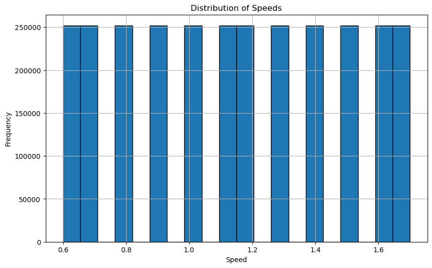

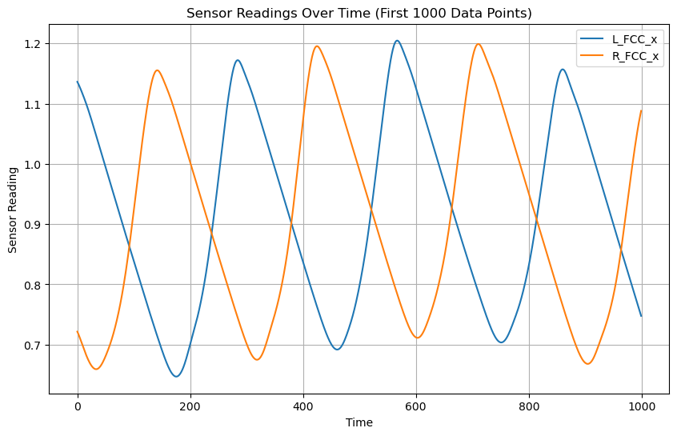

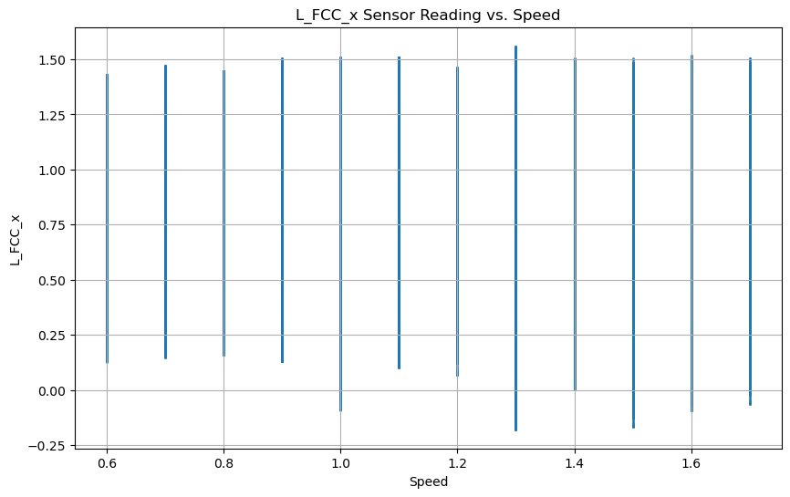

```python
import matplotlib.pyplot as plt

# Histogram of Speeds
plt.figure(figsize=(10, 6))
plt.hist(combined_data['speed'], bins=20, edgecolor='k')
plt.title('Distribution of Speeds')
plt.xlabel('Speed')
plt.ylabel('Frequency')
plt.grid(True)
plt.show()

# Time Series Plot of a sample sensor reading over time
plt.figure(figsize=(10, 6))
plt.plot(combined_data['L_FCC_x'][:1000], label='L_FCC_x')
plt.plot(combined_data['R_FCC_x'][:1000], label='R_FCC_x')
plt.title('Sensor Readings Over Time (First 1000 Data Points)')
plt.xlabel('Time')
plt.ylabel('Sensor Reading')
plt.legend()
plt.grid(True)
plt.show()

# Scatter Plot of Sensor Reading vs. Speed
plt.figure(figsize=(10, 6))
plt.scatter(combined_data['speed'], combined_data['L_FCC_x'], alpha=0.5, s=1)
plt.title('L_FCC_x Sensor Reading vs. Speed')
plt.xlabel('Speed')
plt.ylabel('L_FCC_x')
plt.grid(True)
plt.show()
```

This is a effective visualization techniques to extract meaningful information from the dataset, facilitating data exploration and potential hypothesis generation.

[figure not shown]

```python
import matplotlib.pyplot as plt
from mpl_toolkits.mplot3d import Axes3D

# Get the unique speed values in the dataset
unique_speeds = sorted(combined_data['speed'].unique())

# Determine the grid size
n_rows = 4  # Number of rows of plots
n_cols = 4  # Number of columns of plots
fig, axes = plt.subplots(nrows=n_rows, ncols=n_cols, figsize=(15, 15), subplot_kw={'projection': '3d'})

# Flatten the axes array for easy iteration
axes = axes.flatten()

# Markers and colors for plotting (including both left and right markers)
markers = ['L_FCC', 'L_FM1', 'L_FM2', 'L_FM5', 'R_FCC', 'R_FM1', 'R_FM2', 'R_FM5']
colors = ['r', 'g', 'b', 'y', 'c', 'm', 'orange', 'purple']  # Add more colors if necessary

# Loop through each speed and create a 3D scatter plot in each subplot
for i, speed in enumerate(unique_speeds[:n_rows * n_cols]):
    ax = axes[i]
    speed_data = combined_data[combined_data['speed'] == speed]

    for j, marker in enumerate(markers):
        ax.scatter(speed_data[f'{marker}_x'], speed_data[f'{marker}_y'], speed_data[f'{marker}_z'],
                   c=colors[j], label=marker, s=1)

    # Set title and labels
    ax.set_title(f'Speed {speed} m/s')
    ax.set_xlabel('X')
    ax.set_ylabel('Y')
    ax.set_zlabel('Z')

# Hide unused subplots
for j in range(i + 1, len(axes)):
    axes[j].set_visible(False)
plt.tight_layout()
plt.show()
```

#### 2.4 Handling Missing Values and duplicates

```python
# Check for missing values
missing_values = combined_data.isnull().sum()
print("Missing values in each column:")
print(missing_values)
```

[output not shown]

This Python code replaces missing values in a DataFrame with the average value of each column. It then checks if any missing values remain and prints the results, confirming the success of the imputation.

```python
# Impute missing values with the mean of each column
combined_data_imputed = combined_data.fillna(combined_data.mean())

# Verify that there are no more missing values
missing_values_after_imputation = combined_data_imputed.isnull().sum()
print("Missing values after imputation:\n", missing_values_after_imputation)
```

[output not shown]

```python
duplicates = combined_data[combined_data.duplicated()]
print("Duplicate rows:\n", duplicates)
```

[output not shown]

### 3. Feature Engineering

#### 3.1 Calculation of Euclidean Distances

. To capture the spatial relationships between different parts of the foot during walking, we calculate the Euclidean distances between various markers on the left and right foot.

#### 3.2 Velocity Calculations

```python
import numpy as np

# Function to calculate the Euclidean distance between two sets of points
def euclidean_distance(df, p1, p2):
    return np.sqrt((df[f'{p1}_x'] - df[f'{p2}_x'])**2 +
                   (df[f'{p1}_y'] - df[f'{p2}_y'])**2 +
                   (df[f'{p1}_z'] - df[f'{p2}_z'])**2)

# Extract features: distances between markers on the left foot
combined_data_imputed['L_FCC_L_FM1_dist'] = euclidean_distance(combined_data_imputed, 'L_FCC', 'L_FM1')
combined_data_imputed['L_FCC_L_FM2_dist'] = euclidean_distance(combined_data_imputed, 'L_FCC', 'L_FM2')
combined_data_imputed['L_FCC_L_FM5_dist'] = euclidean_distance(combined_data_imputed, 'L_FCC', 'L_FM5')
combined_data_imputed['L_FM1_L_FM2_dist'] = euclidean_distance(combined_data_imputed, 'L_FM1', 'L_FM2')
combined_data_imputed['L_FM1_L_FM5_dist'] = euclidean_distance(combined_data_imputed, 'L_FM1', 'L_FM5')
combined_data_imputed['L_FM2_L_FM5_dist'] = euclidean_distance(combined_data_imputed, 'L_FM2', 'L_FM5')

# Extract features: distances between markers on the right foot
combined_data_imputed['R_FCC_R_FM1_dist'] = euclidean_distance(combined_data_imputed, 'R_FCC', 'R_FM1')
combined_data_imputed['R_FCC_R_FM2_dist'] = euclidean_distance(combined_data_imputed, 'R_FCC', 'R_FM2')
combined_data_imputed['R_FCC_R_FM5_dist'] = euclidean_distance(combined_data_imputed, 'R_FCC', 'R_FM5')
combined_data_imputed['R_FM1_R_FM2_dist'] = euclidean_distance(combined_data_imputed, 'R_FM1', 'R_FM2')
combined_data_imputed['R_FM1_R_FM5_dist'] = euclidean_distance(combined_data_imputed, 'R_FM1', 'R_FM5')
combined_data_imputed['R_FM2_R_FM5_dist'] = euclidean_distance(combined_data_imputed, 'R_FM2', 'R_FM5')

# Extract velocities for markers on the left foot
combined_data_imputed['L_FCC_velocity'] = np.sqrt(combined_data_imputed['L_FCC_x'].diff()**2 + combined_data_imputed['L_FCC_y'].diff()**2 + combined_data_imputed['L_FCC_z'].diff()**2)
combined_data_imputed['L_FM1_velocity'] = np.sqrt(combined_data_imputed['L_FM1_x'].diff()**2 + combined_data_imputed['L_FM1_y'].diff()**2 + combined_data_imputed['L_FM1_z'].diff()**2)
combined_data_imputed['L_FM2_velocity'] = np.sqrt(combined_data_imputed['L_FM2_x'].diff()**2 + combined_data_imputed['L_FM2_y'].diff()**2 + combined_data_imputed['L_FM2_z'].diff()**2)
combined_data_imputed['L_FM5_velocity'] = np.sqrt(combined_data_imputed['L_FM5_x'].diff()**2 + combined_data_imputed['L_FM5_y'].diff()**2 + combined_data_imputed['L_FM5_z'].diff()**2)

# Extract velocities for markers on the right foot
combined_data_imputed['R_FCC_velocity'] = np.sqrt(combined_data_imputed['R_FCC_x'].diff()**2 + combined_data_imputed['R_FCC_y'].diff()**2 + combined_data_imputed['R_FCC_z'].diff()**2)
combined_data_imputed['R_FM1_velocity'] = np.sqrt(combined_data_imputed['R_FM1_x'].diff()**2 + combined_data_imputed['R_FM1_y'].diff()**2 + combined_data_imputed['R_FM1_z'].diff()**2)
combined_data_imputed['R_FM2_velocity'] = np.sqrt(combined_data_imputed['R_FM2_x'].diff()**2 + combined_data_imputed['R_FM2_y'].diff()**2 + combined_data_imputed['R_FM2_z'].diff()**2)
combined_data_imputed['R_FM5_velocity'] = np.sqrt(combined_data_imputed['R_FM5_x'].diff()**2 + combined_data_imputed['R_FM5_y'].diff()**2 + combined_data_imputed['R_FM5_z'].diff()**2)

# Drop the first row with NaN values due to velocity calculation
combined_data_imputed = combined_data_imputed.dropna().reset_index(drop=True)

combined_data_imputed.info()
```

[output not shown]

```python
combined_data_imputed.head()
```

[output not shown]

#### 3.3 Correlation Analysis

```python
import matplotlib.pyplot as plt
import seaborn as sns

# Set up the matplotlib figure
plt.figure(figsize=(20, 10))

# Plot histograms of the distances
for i, column in enumerate(combined_data_imputed.columns[25:37]):
    plt.subplot(3, 4, i + 1)
    sns.histplot(combined_data_imputed[column], kde=True)
    plt.title(column)
plt.tight_layout()
plt.show()
```

[output not shown]

```python
# Plot histograms of the velocities
plt.figure(figsize=(20, 10))
for i, column in enumerate(combined_data_imputed.columns[37:45]):
    plt.subplot(2, 4, i + 1)
    sns.histplot(combined_data_imputed[column], kde=True)
    plt.title(column)
plt.tight_layout()
plt.show()
```

[output not shown]

```python
# Plot scatter plots to see the relationship between speed and distances
plt.figure(figsize=(20, 10))
for i, column in enumerate(combined_data_imputed.columns[25:37]):
    plt.subplot(3, 4, i + 1)
    sns.scatterplot(x=combined_data_imputed['speed'], y=combined_data_imputed[column])
    plt.title(f'speed vs {column}')
plt.tight_layout()
plt.show()
```

[output not shown]

```python
import seaborn as sns
# Plot scatter plots to see the relationship between speed and velocities
plt.figure(figsize=(20, 10))
for i, column in enumerate(combined_data_imputed.columns[37:45]):
    plt.subplot(2, 4, i + 1)
    sns.scatterplot(x=combined_data_imputed['speed'], y=combined_data_imputed[column])
    plt.title(f'speed vs {column}')
plt.tight_layout()
plt.show()
```

[output not shown]

```python
import matplotlib.pyplot as plt
import seaborn as sns

# Ensure all columns are numeric
numeric_data = combined_data_imputed.select_dtypes(include=[float, int])

# Calculate the correlation matrix
correlation_matrix = numeric_data.corr()

# Plot the heatmap
plt.figure(figsize=(30, 30))
sns.heatmap(correlation_matrix, annot=True, fmt='.2f', cmap='coolwarm', square=True)
plt.title('Correlation Matrix')
plt.show()
```

[output not shown]

### 4. Data Standardization and PCA

#### 4.1 Standardization and Normalization

The features are standardized and normalized to ensure that all features contribute equally to the model.

```python
from sklearn.preprocessing import StandardScaler, MinMaxScaler
import pandas as pd

# Standardize the data (excluding 'speed' column)
scaler = StandardScaler()
data_standardized = scaler.fit_transform(combined_data_imputed.drop(columns=['speed']))

# Normalize the data (excluding 'speed' column)
normalizer = MinMaxScaler()
data_normalized = normalizer.fit_transform(combined_data_imputed.drop(columns=['speed']))

# Convert the scaled numpy arrays back to DataFrame
data_standardized = pd.DataFrame(data_standardized, columns=combined_data_imputed.columns[:-1])
data_normalized = pd.DataFrame(data_normalized, columns=combined_data_imputed.columns[:-1])

# Add the 'speed' column back to each DataFrame
data_standardized['speed'] = combined_data_imputed['speed']
data_normalized['speed'] = combined_data_imputed['speed']

# Display the first few rows of the normalized and standardized datasets to verify
print("Normalized Data:")
print(data_normalized.head())
print("\nStandardized Data:")
print(data_standardized.head())
```

[output not shown]

```python
data_standardized.info()
```

[output not shown]

```python
# Check for missing values in the entire DataFrame
missing_values = data_standardized.isnull().sum()

# Display columns with missing values
print(missing_values[missing_values > 0])
```

[output not shown]

#### 4.2 Principal Component Analysis (PCA)

```python
from sklearn.decomposition import PCA

# Initialize PCA, let's say we want to retain 95% of the variance
pca = PCA(n_components=0.95)
data_pca = pca.fit_transform(data_standardized.drop(columns=['speed']))

# Convert the PCA output array back to a DataFrame
data_pca = pd.DataFrame(data_pca, columns=[f'PC{i+1}' for i in range(data_pca.shape[1])])

# Add the 'speed' column back to the PCA-transformed data
data_pca['speed'] = data_standardized['speed']

# Check the new shape and the DataFrame
print("New shape of the dataset:", data_pca.shape)
print(data_pca.head())

# Explained variance ratio can be checked to understand the amount of variance captured by each principal component
print("Explained Variance Ratio:", pca.explained_variance_ratio_)
```

[output not shown]

```python
data_pca.info()
```

[output not shown]

```python
# Check for missing values in the entire DataFrame
missing_values = data_pca.isnull().sum()

# Display columns with missing values
print(missing_values[missing_values > 0])
```

[output not shown]

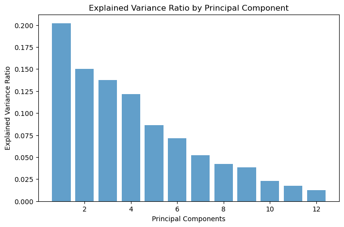

```python
import matplotlib.pyplot as plt

# Plot the explained variance ratio
plt.figure(figsize=(8, 5))
plt.bar(range(1, len(pca.explained_variance_ratio_) + 1), pca.explained_variance_ratio_, alpha=0.7, align='center')
plt.xlabel('Principal Components')
plt.ylabel('Explained Variance Ratio')
plt.title('Explained Variance Ratio by Principal Component')
plt.show()
```

#### 4.3 Speed Binning and Encoding

. The speed column is binned into categorical labels . One-hot encoding is applied to the speed categories for use in machine learning models.

```python
import pandas as pd

# continuous variable to discretize
# Define the bins and labels for speed
bins = [0.5, 0.8, 1.0, 1.2, 1.5, 1.8]
labels = ['Very Slow', 'Slow', 'Medium', 'Fast', 'Very Fast']

# Binning the 'speed' column with defined bins and labels
data_pca['speed_category'] = pd.cut(data_pca['speed'], bins=bins, labels=labels, include_lowest=True)

# Check the distribution of the new categorical column
print("Distribution of binned speed categories:")
print(data_pca['speed_category'].value_counts())

# Encoding the 'speed_category' using one-hot encoding for use in most machine learning models
speed_encoded = pd.get_dummies(data_pca['speed_category'], prefix='speed')

# Append encoded DataFrame back to the main DataFrame
data_pca_encoded = pd.concat([data_pca.drop('speed_category', axis=1), speed_encoded], axis=1)
print("\nEncoded DataFrame:")
print(data_pca_encoded.head())
```

```
Distribution of binned speed categories:
speed_category
Fast         756000
Very Slow    755999
Slow         504000
Medium       504000
Very Fast    504000
Name: count, dtype: int64

Encoded DataFrame:
        PC1       PC2       PC3       PC4       PC5       PC6       PC7  \
0 -3.720544  2.026524 -2.769250  0.219422 -0.179672 -1.484368  2.024593
1 -3.741455  1.985653 -2.682099  0.170426 -0.188521 -1.508438  2.052063
2 -3.762012  1.942537 -2.602436  0.117497 -0.199819 -1.533250  2.080148
3 -3.781665  1.897734 -2.531680  0.061169 -0.213406 -1.558371  2.108269
4 -3.800401  1.851749 -2.470488  0.002046 -0.229087 -1.583200  2.135803

        PC8       PC9      PC10      PC11      PC12  speed  speed_Very Slow  \
0 -0.619933  1.538575  0.115314  0.122695 -0.902006    0.6             True
1 -0.597099  1.530943  0.043858  0.108408 -0.889888    0.6             True
2 -0.573548  1.522239 -0.030778  0.092311 -0.876347    0.6             True
3 -0.549286  1.512746 -0.107983  0.073867 -0.861559    0.6             True
4 -0.523823  1.502238 -0.186723  0.053293 -0.845515    0.6             True

   speed_Slow  speed_Medium  speed_Fast  speed_Very Fast
0       False         False       False            False
1       False         False       False            False
2       False         False       False            False
3       False         False       False            False
4       False         False       False            False
```

```python
print(data_pca_encoded.tail())
```

```
              PC1       PC2       PC3       PC4       PC5       PC6       PC7  \
3023994  5.458927 -5.406395 -2.205191 -1.693118 -0.276787  2.506403  0.031023
3023995  5.451032 -5.442389 -2.565012 -1.675557 -0.370825  2.483157  0.001777
3023996  5.438561 -5.468640 -2.869553 -1.662695 -0.456752  2.464850 -0.019747
3023997  5.423950 -5.489138 -3.078476 -1.661131 -0.525789  2.454736 -0.032347
3023998  5.408987 -5.504665 -3.165974 -1.669574 -0.572659  2.455287 -0.035397

              PC8       PC9      PC10      PC11      PC12  speed  \
3023994  2.569847 -1.598452  2.987170  1.292993 -0.721067    1.7
3023995  2.606971 -1.602304  3.000488  1.283795 -0.704232    1.7
3023996  2.598184 -1.612901  2.999996  1.271805 -0.687911    1.7
3023997  2.527903 -1.631218  2.990183  1.259519 -0.673039    1.7
3023998  2.402320 -1.656021  2.972929  1.248176 -0.660778    1.7

         speed_Very Slow  speed_Slow  speed_Medium  speed_Fast  \
3023994            False       False         False       False
3023995            False       False         False       False
3023996            False       False         False       False
3023997            False       False         False       False
3023998            False       False         False       False

         speed_Very Fast
3023994             True
3023995             True
3023996             True
3023997             True
3023998             True
```

### 5. Machine Learning Model Building

#### 5.1 Random Forest Classifier

. The Random Forest classifier is trained on the PCA-transformed features. . The model is evaluated using a classification report and confusion matrix. . Visualization of the confusion matrix and classification report is provided.

```python
# Import necessary libraries
from sklearn.ensemble import RandomForestClassifier
from sklearn.metrics import classification_report, confusion_matrix
from sklearn.model_selection import train_test_split

# Separate features and target variables
X = data_pca_encoded.drop(['speed', 'speed_Very Slow', 'speed_Slow', 'speed_Medium', 'speed_Fast', 'speed_Very Fast'], axis=1)
y = data_pca_encoded.loc[:, 'speed_Very Slow':'speed_Very Fast']

# Convert y to single column of class labels
y_labels = y.idxmax(axis=1)

# Split the data into training and testing sets
X_train, X_test, y_train, y_test = train_test_split(X, y_labels, test_size=0.25, random_state=42)
```

Train a Random Forest classifier on a dataset and evaluates its performance using a classification report and confusion matrix, which provide detailed insights into the model's accuracy and error distribution across different classes. The results are printed to the console for assessment.

```python
from sklearn.ensemble import RandomForestClassifier
from sklearn.metrics import classification_report, confusion_matrix

# Initialize the Random Forest Classifier
rf_clf = RandomForestClassifier(n_estimators=100, random_state=42)

# Train the model on the full training data
rf_clf.fit(X_train, y_train)

# Predict on the test data
y_pred_rf = rf_clf.predict(X_test)

# Evaluation
print("Random Forest Classifier")
print("Classification Report:")
print(classification_report(y_test, y_pred_rf, zero_division=0))

print("\nConfusion Matrix:")
print(confusion_matrix(y_test, y_pred_rf))
```

```
Random Forest Classifier
Classification Report:
                 precision    recall  f1-score   support

     speed_Fast       0.98      0.99      0.99    189004
   speed_Medium       0.99      0.99      0.99    126051
     speed_Slow       0.99      0.99      0.99    126155
speed_Very Fast       0.99      0.98      0.99    125903
speed_Very Slow       1.00      1.00      1.00    188887

       accuracy                           0.99    756000
      macro avg       0.99      0.99      0.99    756000
   weighted avg       0.99      0.99      0.99    756000


Confusion Matrix:
[[186642    615     31   1676     40]
 [   959 124352    683      4     53]
 [    10    680 124723      1    741]
 [  2009     23     11 123847     13]
 [     3      5    412      4 188463]]
```

Generates a confusion matrix heatmap to visualize the Random Forest classifier's prediction accuracy and a bar chart of the classification report showing precision, recall, and F1-scores for each class. These visuals help assess the model's performance in detail.

[figure not shown]

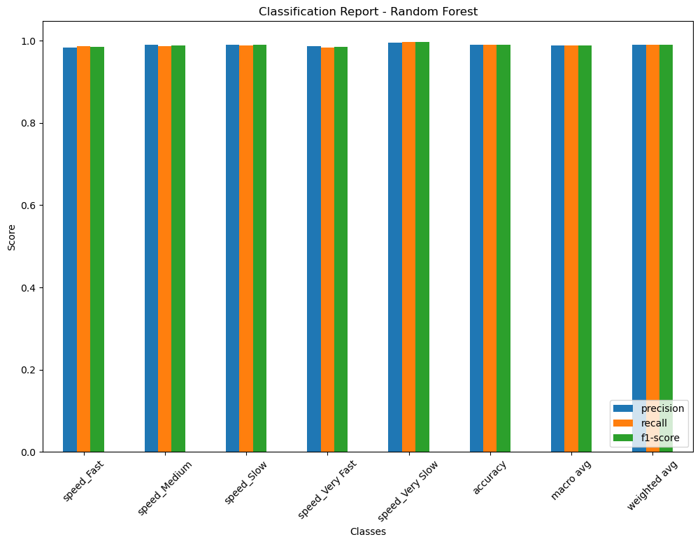

```python
import matplotlib.pyplot as plt
import seaborn as sns
import pandas as pd

# Confusion Matrix Heatmap
conf_matrix_rf = confusion_matrix(y_test, y_pred_rf)
plt.figure(figsize=(10, 7))
sns.heatmap(conf_matrix_rf, annot=True, fmt='d', cmap='Blues', xticklabels=y_test.unique(), yticklabels=y_test.unique())
plt.title('Confusion Matrix - Random Forest')
plt.xlabel('Predicted Labels')
plt.ylabel('True Labels')
plt.show()

# Classification Report Bar Chart
class_report_rf = classification_report(y_test, y_pred_rf, output_dict=True, zero_division=0)
report_df_rf = pd.DataFrame(class_report_rf).transpose()

report_df_rf[['precision', 'recall', 'f1-score']].plot(kind='bar', figsize=(12, 8))
plt.title('Classification Report - Random Forest')
plt.ylabel('Score')
plt.xlabel('Classes')
plt.xticks(rotation=45)
plt.legend(loc='lower right')
plt.show()
```

A DataFrame of misclassified samples by comparing the true and predicted labels from the test set, along with their associated feature data. It then filters out correctly classified samples, displaying only those that were misclassified for further analysis.

```python
# Create a DataFrame to hold the true labels, predicted labels, and the associated feature data
misclassified_samples = pd.DataFrame({
    'True_Label': y_test,
    'Predicted_Label': y_pred_rf
})

# Add the features
misclassified_samples = pd.concat([misclassified_samples, X_test.reset_index(drop=True)], axis=1)

# Filter out the correctly classified samples
misclassified_samples = misclassified_samples[misclassified_samples['True_Label'] != misclassified_samples['Predicted_Label']]
print(misclassified_samples)
```

```
              True_Label  Predicted_Label       PC1       PC2       PC3  \
2991105       speed_Fast  speed_Very Fast       NaN       NaN       NaN
846204   speed_Very Fast       speed_Fast       NaN       NaN       NaN
1417113  speed_Very Fast       speed_Fast       NaN       NaN       NaN
2939441       speed_Slow     speed_Medium       NaN       NaN       NaN
269423   speed_Very Fast       speed_Fast  2.338915  3.132220 -1.660018
...                  ...              ...       ...       ...       ...
755995               NaN              NaN  2.305379 -1.922224  2.252056
755996               NaN              NaN  2.823539  5.360371 -1.277728
755997               NaN              NaN -0.734858 -2.579570 -0.333054
755998               NaN              NaN  2.689519  3.476786  2.081446
755999               NaN              NaN -1.153312 -0.914437 -0.801864

              PC4       PC5       PC6       PC7       PC8       PC9      PC10  \
2991105       NaN       NaN       NaN       NaN       NaN       NaN       NaN
```

[output cut: 25 more lines]

Filters out misclassified samples with missing principal component values and then plots these samples in the PC1 vs. PC2 space, color-coded by their true labels. The scatter plot helps visualize patterns in the misclassification based on PCA values.

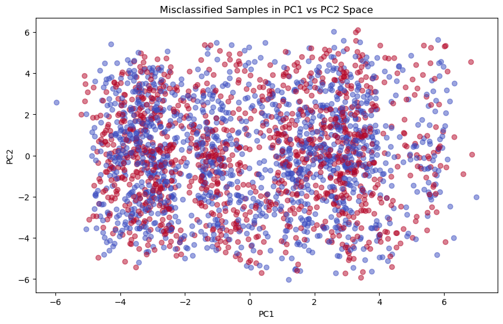

```python
# Filter out rows with NaN values in the PC columns
misclassified_samples_clean = misclassified_samples.dropna()

# Plot the first two principal components for visualization
import matplotlib.pyplot as plt

plt.figure(figsize=(10, 6))
plt.scatter(misclassified_samples_clean['PC1'], misclassified_samples_clean['PC2'],
            c=misclassified_samples_clean['True_Label'].apply(lambda x: 0 if 'Fast' in x else 1),
            cmap='coolwarm', alpha=0.5)
plt.xlabel('PC1')
plt.ylabel('PC2')
plt.title('Misclassified Samples in PC1 vs PC2 Space')
plt.show()
```

The misclassification rate by comparing the true and predicted labels, then dividing the number of misclassified samples by the total number of samples. The results include the total misclassified samples, total samples, and the misclassification rate, providing insight into the model's performance.

```python
# Create a Boolean mask for misclassified samples
misclassified_mask = y_test != y_pred_rf

# Count the total number of misclassified samples
total_misclassified = misclassified_mask.sum()

# Calculate the total number of samples
total_samples = len(y_test)

# Calculate the misclassification rate
misclassification_rate = total_misclassified / total_samples

print(f"Total Misclassified Samples: {total_misclassified}")
print(f"Total Samples: {total_samples}")
print(f"Misclassification Rate: {misclassification_rate:.4f}")
```

```
Total Misclassified Samples: 7973
Total Samples: 756000
Misclassification Rate: 0.0105
```

A bar chart of feature importances from the Random Forest model, displaying the features in descending order of their contribution to the model.

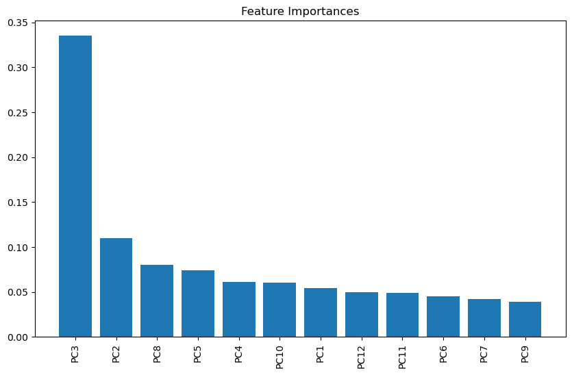

```python
# Plotting feature importances
importances = rf_clf.feature_importances_
indices = np.argsort(importances)[::-1]

plt.figure(figsize=(10, 6))
plt.title("Feature Importances")
plt.bar(range(X_train.shape[1]), importances[indices], align="center")
plt.xticks(range(X_train.shape[1]), [X_train.columns[i] for i in indices], rotation=90)
plt.show()
```

#### 5.2 LOGISTIC REGRESSION

Train a Logistic Regression model on the training data, predicts labels for the test data, and then evaluates its performance using a classification report and confusion matrix. The results provide insights into the model's accuracy and error distribution across classes.

```python
from sklearn.linear_model import LogisticRegression

# Logistic Regression Classifier
lr_clf = LogisticRegression(max_iter=1000, random_state=42)
lr_clf.fit(X_train, y_train)
y_pred_lr = lr_clf.predict(X_test)

print("Logistic Regression Classifier")
print("Classification Report:")
print(classification_report(y_test, y_pred_lr, zero_division=0))
print("\nConfusion Matrix:")
print(confusion_matrix(y_test, y_pred_lr))
```

```
Logistic Regression Classifier
Classification Report:
                 precision    recall  f1-score   support

     speed_Fast       0.38      0.58      0.46    189004
   speed_Medium       0.26      0.09      0.14    126051
     speed_Slow       0.27      0.11      0.16    126155
speed_Very Fast       0.61      0.49      0.55    125903
speed_Very Slow       0.54      0.79      0.64    188887

       accuracy                           0.46    756000
      macro avg       0.41      0.41      0.39    756000
   weighted avg       0.42      0.46      0.42    756000


Confusion Matrix:
[[109462   8645  11825  37269  21803]
 [ 64070  11654   5272   1654  43401]
 [ 39685  12965  13697    137  59671]
 [ 56355   3383   2911  62269    985]
 [ 14985   8468  16852     66 148516]]
```

Visualizes the Logistic Regression model's performance by plotting a confusion matrix heatmap and a bar chart of precision, recall, and F1-scores.

[figure not shown]

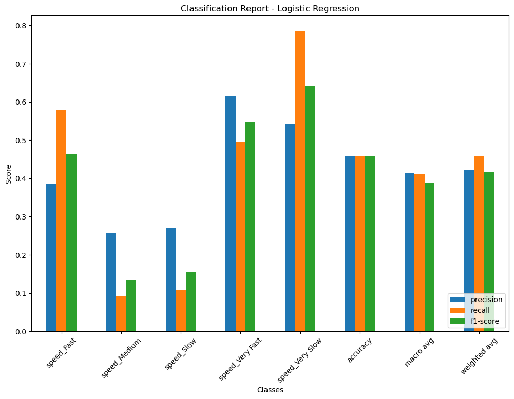

```python
conf_matrix_lr = confusion_matrix(y_test, y_pred_lr)
class_report_lr = classification_report(y_test, y_pred_lr, output_dict=True, zero_division=0)

# Plotting the Confusion Matrix for Logistic Regression
plt.figure(figsize=(10, 7))
sns.heatmap(conf_matrix_lr, annot=True, fmt='d', cmap='Blues', xticklabels=y_test.unique(), yticklabels=y_test.unique())
plt.title('Confusion Matrix - Logistic Regression')
plt.xlabel('Predicted Labels')
plt.ylabel('True Labels')
plt.show()

# Plotting the Classification Report for Logistic Regression
report_df_lr = pd.DataFrame(class_report_lr).transpose()

report_df_lr[['precision', 'recall', 'f1-score']].plot(kind='bar', figsize=(12, 8))
plt.title('Classification Report - Logistic Regression')
plt.ylabel('Score')
plt.xlabel('Classes')
plt.xticks(rotation=45)
plt.legend(loc='lower right')
plt.show()
```

#### Logistic Regression with L1 Regularization and L2 Regularization

Train and evaluate Logistic Regression models with L1 (Lasso) and L2 (Ridge) regularization, comparing their overall accuracy, classification reports, and confusion matrices. It helps assess the impact of each regularization method on model performance.

L1 Regularization (Lasso) encourages sparsity in the model by shrinking the coefficients of less important features to zero, effectively performing feature selection. . L2 Regularization (Ridge), on the other hand, distributes the error more evenly across all features, which helps in preventing overfitting by penalizing large coefficients.

```python
from sklearn.linear_model import LogisticRegression
from sklearn.metrics import classification_report, confusion_matrix, accuracy_score
from sklearn.model_selection import train_test_split

# L1 Regularization (Lasso)
lr_l1 = LogisticRegression(penalty='l1', solver='liblinear', C=1.0, max_iter=1000, random_state=42)
lr_l1.fit(X_train, y_train)
y_pred_l1 = lr_l1.predict(X_test)

print("Logistic Regression with L1 Regularization")
print("Overall Accuracy:", accuracy_score(y_test, y_pred_l1))
print("\nClassification Report:")
print(classification_report(y_test, y_pred_l1, zero_division=0))
print("\nConfusion Matrix:")
print(confusion_matrix(y_test, y_pred_l1))

# L2 Regularization (Ridge)
lr_l2 = LogisticRegression(penalty='l2', solver='lbfgs', C=1.0, max_iter=1000, random_state=42)
lr_l2.fit(X_train, y_train)
y_pred_l2 = lr_l2.predict(X_test)

print("\nLogistic Regression with L2 Regularization")
print("Overall Accuracy:", accuracy_score(y_test, y_pred_l2))
print("\nClassification Report:")
print(classification_report(y_test, y_pred_l2, zero_division=0))
print("\nConfusion Matrix:")
print(confusion_matrix(y_test, y_pred_l2))
```

```
Logistic Regression with L1 Regularization
Overall Accuracy: 0.4677420634920635

Classification Report:
                 precision    recall  f1-score   support

     speed_Fast       0.37      0.63      0.46    189004
   speed_Medium       0.36      0.03      0.06    126051
     speed_Slow       0.49      0.05      0.10    126155
speed_Very Fast       0.63      0.48      0.54    125903
speed_Very Slow       0.52      0.86      0.65    188887

       accuracy                           0.47    756000
      macro avg       0.47      0.41      0.36    756000
   weighted avg       0.47      0.47      0.40    756000


Confusion Matrix:
[[118729   1164   2100  34800  32211]
 [ 71496   4216   1331   1158  47850]
 [ 48618   4915   6888     75  65659]
 [ 61337    387    464  60581   3134]
 [ 21506    943   3176     63 163199]]

Logistic Regression with L2 Regularization
Overall Accuracy: 0.4571402116402116

Classification Report:
                 precision    recall  f1-score   support

     speed_Fast       0.38      0.58      0.46    189004
   speed_Medium       0.26      0.09      0.14    126051
     speed_Slow       0.27      0.11      0.16    126155
speed_Very Fast       0.61      0.49      0.55    125903
speed_Very Slow       0.54      0.79      0.64    188887

       accuracy                           0.46    756000
      macro avg       0.41      0.41      0.39    756000
   weighted avg       0.42      0.46      0.42    756000


Confusion Matrix:
[[109462   8645  11825  37269  21803]
 [ 64070  11654   5272   1654  43401]
 [ 39685  12965  13697    137  59671]
 [ 56355   3383   2911  62269    985]
 [ 14985   8468  16852     66 148516]]
```

Train a Logistic Regression model with balanced class weights, performs 5-fold cross-validation, and evaluates its performance using accuracy, classification reports, and a confusion matrix. It addresses class imbalance and assesses model effectiveness across training and test data.

```python
from sklearn.linear_model import LogisticRegression
from sklearn.model_selection import cross_val_score
from sklearn.metrics import classification_report, confusion_matrix, accuracy_score

# Define the Logistic Regression model with class weights
lr_clf = LogisticRegression(max_iter=1000, random_state=42, class_weight='balanced')

# Perform cross-validation
cv_scores = cross_val_score(lr_clf, X_train, y_train, cv=5, scoring='accuracy')
print("Cross-validation scores:", cv_scores)
print("Mean cross-validation score:", cv_scores.mean())

# Train and predict
lr_clf.fit(X_train, y_train)
y_pred_lr = lr_clf.predict(X_test)

# Evaluation
print("Logistic Regression Classifier")
print("Overall Accuracy:", accuracy_score(y_test, y_pred_lr))
print("\nClassification Report:")
print(classification_report(y_test, y_pred_lr, zero_division=0))
print("\nConfusion Matrix:")
print(confusion_matrix(y_test, y_pred_lr))
```

```
Cross-validation scores: [0.40557981 0.40515653 0.40445326 0.40383818 0.40512876]
Mean cross-validation score: 0.4048313073759961
Logistic Regression Classifier
Overall Accuracy: 0.4049708994708995

Classification Report:
                 precision    recall  f1-score   support

     speed_Fast       0.36      0.24      0.29    189004
   speed_Medium       0.26      0.25      0.25    126051
     speed_Slow       0.20      0.20      0.20    126155
speed_Very Fast       0.47      0.66      0.55    125903
speed_Very Slow       0.60      0.64      0.62    188887

       accuracy                           0.40    756000
      macro avg       0.38      0.40      0.38    756000
   weighted avg       0.39      0.40      0.39    756000


Confusion Matrix:
[[ 45692  28346  31107  78642   5217]
 [ 32850  31000  22217  12924  27060]
 [ 19517  29915  25208   1995  49520]
 [ 24052  13233   5510  83041     67]
 [  3691  19019  44715    245 121217]]
```

Calculates the misclassification rate by analyzing the confusion matrix, extracting correct and incorrect classifications. It then prints the confusion matrix, total misclassifications, and classification report to evaluate the Logistic Regression model's performance

```python
import numpy as np
from sklearn.metrics import confusion_matrix, classification_report
# Generate confusion matrix
cm = confusion_matrix(y_test, y_pred_lr)

# Extract the diagonal elements (correct classifications)
correct_classifications = np.diag(cm)

# Sum of all elements in the confusion matrix
total_samples = np.sum(cm)

# Sum of all non-diagonal elements (misclassifications)
total_misclassifications = total_samples - np.sum(correct_classifications)

# Misclassification rate
misclassification_rate = total_misclassifications / total_samples

print("Confusion Matrix:\n", cm)
print("\nTotal Misclassified Samples:", total_misclassifications)
print("Total Samples:", total_samples)
print("Misclassification Rate:", misclassification_rate)
print("\nClassification Report:\n", classification_report(y_test, y_pred_lr))
```

```
Confusion Matrix:
 [[ 45692  28346  31107  78642   5217]
 [ 32850  31000  22217  12924  27060]
 [ 19517  29915  25208   1995  49520]
 [ 24052  13233   5510  83041     67]
 [  3691  19019  44715    245 121217]]

Total Misclassified Samples: 449842
Total Samples: 756000
Misclassification Rate: 0.5950291005291005

Classification Report:
                  precision    recall  f1-score   support

     speed_Fast       0.36      0.24      0.29    189004
   speed_Medium       0.26      0.25      0.25    126051
     speed_Slow       0.20      0.20      0.20    126155
speed_Very Fast       0.47      0.66      0.55    125903
speed_Very Slow       0.60      0.64      0.62    188887

       accuracy                           0.40    756000
      macro avg       0.38      0.40      0.38    756000
   weighted avg       0.39      0.40      0.39    756000
```

Evaluates a Logistic Regression model by calculating training, cross-validation, and testing accuracies, then visualizes these metrics in a plot. The plot compares performance across different stages to assess model generalization and potential overfitting.

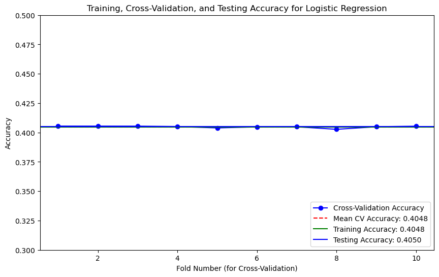

```python
import matplotlib.pyplot as plt
from sklearn.linear_model import LogisticRegression
from sklearn.model_selection import cross_val_score
from sklearn.metrics import accuracy_score

# Define the Logistic Regression model
lr_clf = LogisticRegression(max_iter=1000, random_state=42, class_weight='balanced')

# Perform cross-validation
cv_scores = cross_val_score(lr_clf, X_train, y_train, cv=10, scoring='accuracy')

# Calculate the mean cross-validation accuracy
mean_cv_score = cv_scores.mean()

# Train the model on the entire training set
lr_clf.fit(X_train, y_train)

# Calculate training accuracy
training_accuracy = accuracy_score(y_train, lr_clf.predict(X_train))

# Calculate testing accuracy
testing_accuracy = accuracy_score(y_test, lr_clf.predict(X_test))

# Plotting the accuracies
plt.figure(figsize=(10, 6))

# Cross-validation accuracies
plt.plot(range(1, len(cv_scores) + 1), cv_scores, 'bo-', label='Cross-Validation Accuracy')
plt.axhline(y=mean_cv_score, color='r', linestyle='--', label=f'Mean CV Accuracy: {mean_cv_score:.4f}')

# Training accuracy
plt.axhline(y=training_accuracy, color='g', linestyle='-', label=f'Training Accuracy: {training_accuracy:.4f}')

# Testing accuracy
plt.axhline(y=testing_accuracy, color='b', linestyle='-', label=f'Testing Accuracy: {testing_accuracy:.4f}')

plt.title('Training, Cross-Validation, and Testing Accuracy for Logistic Regression')
plt.xlabel('Fold Number (for Cross-Validation)')
plt.ylabel('Accuracy')
plt.legend(loc='lower right')

plt.ylim([0.3, 0.5])

plt.show()
```

#### 5.3 NEURAL NETWORK

Train a neural network for a classification task by first encoding the labels and then defining a Sequential model with two hidden layers and dropout to prevent overfitting. The model is compiled using the Adam optimizer and trained over 50 epochs, with performance evaluated on test data. The accuracy, classification report, and confusion matrix are generated to provide a detailed assessment of the model's classification performance

```python
import tensorflow as tf
from tensorflow.keras.models import Sequential
from tensorflow.keras.layers import Dense, Dropout
from tensorflow.keras.optimizers import Adam
from sklearn.preprocessing import LabelEncoder
from sklearn.metrics import classification_report, confusion_matrix
from sklearn.model_selection import train_test_split

# Step 1: Convert string labels to integers
label_encoder = LabelEncoder()
y_train_encoded = label_encoder.fit_transform(y_train)
y_test_encoded = label_encoder.transform(y_test)

# Step 2: One-hot encode the labels
y_train_onehot = tf.keras.utils.to_categorical(y_train_encoded)
y_test_onehot = tf.keras.utils.to_categorical(y_test_encoded)

# Define the model
model = Sequential()

# Input layer and first hidden layer
model.add(Dense(128, input_dim=X_train.shape[1], activation='relu'))
model.add(Dropout(0.5))  # Dropout layer to prevent overfitting

# Second hidden layer
model.add(Dense(64, activation='relu'))
model.add(Dropout(0.5))

# Output layer
model.add(Dense(y_train_onehot.shape[1], activation='softmax'))

# Compile the model
model.compile(optimizer=Adam(learning_rate=0.001),
              loss='categorical_crossentropy',
              metrics=['accuracy'])

# Train the model
history = model.fit(X_train, y_train_onehot,
                    validation_data=(X_test, y_test_onehot),
                    epochs=50, batch_size=64, verbose=2)

# Evaluate the model
scores = model.evaluate(X_test, y_test_onehot, verbose=0)
print(f"Neural Network Accuracy: {scores[1]:.4f}")

# Predicting on the test data
y_pred_onehot = model.predict(X_test)
y_pred = tf.argmax(y_pred_onehot, axis=1).numpy()

# Convert predictions back to original labels
y_pred_labels = label_encoder.inverse_transform(y_pred)

# Evaluation
print("\nClassification Report:")
print(classification_report(y_test, y_pred_labels, zero_division=0))

print("\nConfusion Matrix:")
print(confusion_matrix(y_test, y_pred_labels))
```

[output not shown]

```python
# Plot training & validation accuracy values
plt.figure(figsize=(12, 6))
plt.plot(history.history['accuracy'], label='Training Accuracy')
plt.plot(history.history['val_accuracy'], label='Validation Accuracy')
plt.title('Model Accuracy')
plt.xlabel('Epochs')
plt.ylabel('Accuracy')
plt.legend(loc='lower right')
plt.show()
```

[output not shown]

```python
import matplotlib.pyplot as plt

# Plot training & validation loss values
plt.figure(figsize=(12, 6))
plt.plot(history.history['loss'], label='Training Loss')
plt.plot(history.history['val_loss'], label='Validation Loss')
plt.title('Model Loss')
plt.xlabel('Epochs')
plt.ylabel('Loss')
plt.legend(loc='upper right')
plt.show()
```

[output not shown]

```python
import seaborn as sns
import matplotlib.pyplot as plt
from sklearn.metrics import ConfusionMatrixDisplay

# Confusion Matrix Visualization
plt.figure(figsize=(10, 7))
cm = confusion_matrix(y_test, y_pred_labels)
sns.heatmap(cm, annot=True, fmt='d', cmap='Blues', xticklabels=label_encoder.classes_, yticklabels=label_encoder.classes_)
plt.title('Confusion Matrix - nueral network ')
plt.xlabel('Predicted Labels')
plt.ylabel('True Labels')
plt.show()
```

[output not shown]

```python
import numpy as np
import matplotlib.pyplot as plt
import seaborn as sns
from sklearn.metrics import classification_report

# Generate the classification report
report = classification_report(y_test, y_pred_labels, output_dict=True, zero_division=0)

# Define the metrics and labels
metrics = ['precision', 'recall', 'f1-score']
labels = list(report.keys())[:-3]  # Extracting class labels

# Create subplots
fig, axes = plt.subplots(1, 3, figsize=(20, 7))

# Plot each metric
for i, metric in enumerate(metrics):
    values = [report[label][metric] for label in labels]
    sns.barplot(ax=axes[i], x=labels, y=values)
    axes[i].set_title(f'{metric.capitalize()} per Class- nueral network ')
    axes[i].set_ylim(0, 1)
    axes[i].set_xlabel('Class')
    axes[i].set_ylabel(metric.capitalize())
plt.tight_layout()
plt.show()
```

[output not shown]

```python
import matplotlib.pyplot as plt

# Extract values from the history object
accuracy = history.history['accuracy']
val_accuracy = history.history['val_accuracy']
loss = history.history['loss']
val_loss = history.history['val_loss']

epochs = range(1, len(accuracy) + 1)

# Plot training and validation accuracy
plt.figure(figsize=(12, 6))

plt.subplot(1, 2, 1)
plt.plot(epochs, accuracy, 'bo-', label='Training Accuracy')
plt.plot(epochs, val_accuracy, 'r*-', label='Validation Accuracy')
plt.title('Training and Validation Accuracy')
plt.xlabel('Epochs')
plt.ylabel('Accuracy')
plt.legend()

# Plot training and validation loss
plt.subplot(1, 2, 2)
plt.plot(epochs, loss, 'bo-', label='Training Loss')
plt.plot(epochs, val_loss, 'r*-', label='Validation Loss')
plt.title('Training and Validation Loss')
plt.xlabel('Epochs')
plt.ylabel('Loss')
plt.legend()

plt.tight_layout()
plt.show()
```

[output not shown]

#### 5.4 GB CLASSIFIER

Train a Gradient Boosting Classifier on the training data, predicts the test labels, and evaluates the model's performance by printing a classification report and confusion matrix. It provides insights into the model's accuracy and classification capabilities

```python
# Import necessary libraries
from sklearn.ensemble import GradientBoostingClassifier

# Gradient Boosting Classifier
gb_clf = GradientBoostingClassifier(n_estimators=100, random_state=42)
gb_clf.fit(X_train, y_train)
y_pred_gb = gb_clf.predict(X_test)

# Evaluation
print("Gradient Boosting Classifier")
print("Classification Report:")
print(classification_report(y_test, y_pred_gb, zero_division=0))
print("\nConfusion Matrix:")
print(confusion_matrix(y_test, y_pred_gb))
```

```
Gradient Boosting Classifier
Classification Report:
                 precision    recall  f1-score   support

     speed_Fast       0.65      0.78      0.71    189004
   speed_Medium       0.61      0.43      0.51    126051
     speed_Slow       0.59      0.51      0.55    126155
speed_Very Fast       0.82      0.73      0.77    125903
speed_Very Slow       0.80      0.93      0.86    188887

       accuracy                           0.71    756000
      macro avg       0.70      0.68      0.68    756000
   weighted avg       0.70      0.71      0.70    756000


Confusion Matrix:
[[148226  14861   5092  19900    925]
 [ 37819  54476  27429    317   6010]
 [  6791  16911  64757     54  37642]
 [ 33363    735    340  91431     34]
 [   528   1690  11645     20 175004]]
```

[figure not shown]

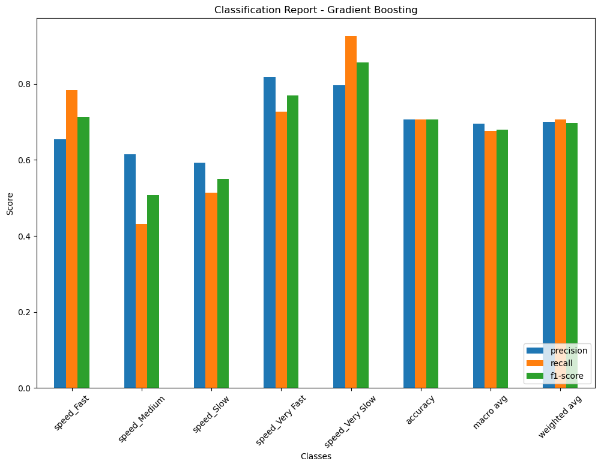

```python
conf_matrix_gb = confusion_matrix(y_test, y_pred_gb)
class_report_gb = classification_report(y_test, y_pred_gb, output_dict=True, zero_division=0)

# Plotting the Confusion Matrix for Gradient Boosting
plt.figure(figsize=(10, 7))
sns.heatmap(conf_matrix_lr, annot=True, fmt='d', cmap='Blues', xticklabels=y_test.unique(), yticklabels=y_test.unique())
plt.title('Confusion Matrix - Gradient Boosting')
plt.xlabel('Predicted Labels')
plt.ylabel('True Labels')
plt.show()

# Plotting the Classification Report for Gradient Boosting
report_df_gb = pd.DataFrame(class_report_gb).transpose()
report_df_gb[['precision', 'recall', 'f1-score']].plot(kind='bar', figsize=(12, 8))
plt.title('Classification Report - Gradient Boosting')
plt.ylabel('Score')
plt.xlabel('Classes')
plt.xticks(rotation=45)
plt.legend(loc='lower right')
plt.show()
```

#### 5.5 KNN CLASSIFIER

Trains a k-Nearest Neighbors (k-NN) classifier on the training data, predicts the test labels, and evaluates the model's performance using a classification report and confusion matrix. It provides insights into the model's accuracy and effectiveness in classifying the test data.

```python
from sklearn.neighbors import KNeighborsClassifier

# k-Nearest Neighbors Classifier
knn_clf = KNeighborsClassifier(n_neighbors=5)
knn_clf.fit(X_train, y_train)
y_pred_knn = knn_clf.predict(X_test)

# Evaluation
print("k-Nearest Neighbors Classifier")
print("Classification Report:")
print(classification_report(y_test, y_pred_knn, zero_division=0))
print("\nConfusion Matrix:")
print(confusion_matrix(y_test, y_pred_knn))
```

```
k-Nearest Neighbors Classifier
Classification Report:
                 precision    recall  f1-score   support

     speed_Fast       0.97      0.97      0.97    189004
   speed_Medium       0.98      0.98      0.98    126051
     speed_Slow       0.98      0.98      0.98    126155
speed_Very Fast       0.98      0.97      0.97    125903
speed_Very Slow       0.99      1.00      0.99    188887

       accuracy                           0.98    756000
      macro avg       0.98      0.98      0.98    756000
   weighted avg       0.98      0.98      0.98    756000


Confusion Matrix:
[[184186   1664     17   3122     15]
 [  1537 123128   1356      1     29]
 [     8   1206 123826      0   1115]
 [  3430      7      8 122451      7]
 [     6      5    820      1 188055]]
```

Visualizes the k-Nearest Neighbors (k-NN) model's performance with a confusion matrix heatmap and a bar chart of precision, recall, and F1-scores.

[figure not shown]

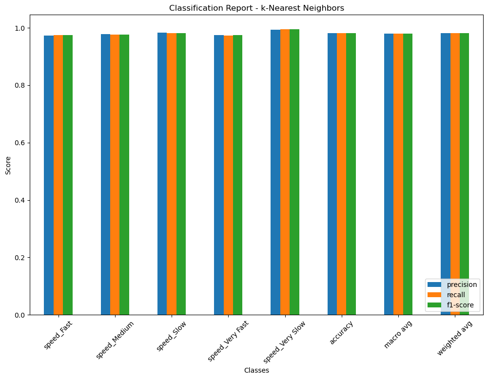

```python
conf_matrix_knn = confusion_matrix(y_test, y_pred_knn)
class_report_knn = classification_report(y_test, y_pred_knn, output_dict=True, zero_division=0)

# Plotting the Confusion Matrix for k-NN
plt.figure(figsize=(10, 7))
sns.heatmap(conf_matrix_knn, annot=True, fmt='d', cmap='Blues', xticklabels=y_test.unique(), yticklabels=y_test.unique())
plt.title('Confusion Matrix - k-Nearest Neighbors')
plt.xlabel('Predicted Labels')
plt.ylabel('True Labels')
plt.show()

# Plotting the Classification Report for k-NN
report_df_knn = pd.DataFrame(class_report_knn).transpose()

report_df_knn[['precision', 'recall', 'f1-score']].plot(kind='bar', figsize=(12, 8))
plt.title('Classification Report - k-Nearest Neighbors')
plt.ylabel('Score')
plt.xlabel('Classes')
plt.xticks(rotation=45)
plt.legend(loc='lower right')
plt.show()
```

Performs 5-fold cross-validation on a k-Nearest Neighbors (k-NN) classifier, printing the accuracy scores for each fold and the mean accuracy. It helps assess the model's generalization across different subsets of the training data.

```python
from sklearn.model_selection import cross_val_score
from sklearn.neighbors import KNeighborsClassifier

# Initialize the k-Nearest Neighbors Classifier
knn_clf = KNeighborsClassifier(n_neighbors=5)

# Perform 5-Fold Cross-Validation
cv_scores = cross_val_score(knn_clf, X_train, y_train, cv=5, scoring='accuracy')

# Print the Cross-Validation scores and their mean
print("Cross-validation scores:", cv_scores)
print("Mean cross-validation score:", cv_scores.mean())
```

```
Cross-validation scores: [0.97203042 0.9720679  0.97209215 0.97190917 0.97188927]
Mean cross-validation score: 0.9719977830199593
```

#### 5.6 DECISION TREE CLASSIFIERS

Trains a Decision Tree classifier on the training data, predicts the test labels, and evaluates the model's performance using a classification report and confusion matrix. It provides insights into the model's accuracy and classification effectiveness

```python
# Import necessary libraries
from sklearn.tree import DecisionTreeClassifier

# Decision Tree Classifier
dt_clf = DecisionTreeClassifier(random_state=42)
dt_clf.fit(X_train, y_train)
y_pred_dt = dt_clf.predict(X_test)

# Evaluation
print("Decision Tree Classifier")
print("Classification Report:")
print(classification_report(y_test, y_pred_dt, zero_division=0))
print("\nConfusion Matrix:")
print(confusion_matrix(y_test, y_pred_dt))
```

```
Decision Tree Classifier
Classification Report:
                 precision    recall  f1-score   support

     speed_Fast       0.92      0.93      0.93    189004
   speed_Medium       0.92      0.91      0.92    126051
     speed_Slow       0.92      0.92      0.92    126155
speed_Very Fast       0.93      0.93      0.93    125903
speed_Very Slow       0.97      0.97      0.97    188887

       accuracy                           0.93    756000
      macro avg       0.93      0.93      0.93    756000
   weighted avg       0.93      0.93      0.93    756000


Confusion Matrix:
[[175053   5411    255   8204     81]
 [  5481 115276   5005     70    219]
 [   228   4884 115730     32   5281]
 [  8569     97     73 117126     38]
 [    47    214   5034     29 183563]]
```

Visualizes the Decision Tree model's performance with a confusion matrix heatmap and a bar chart showing precision, recall, and F1-scores

[figure not shown]

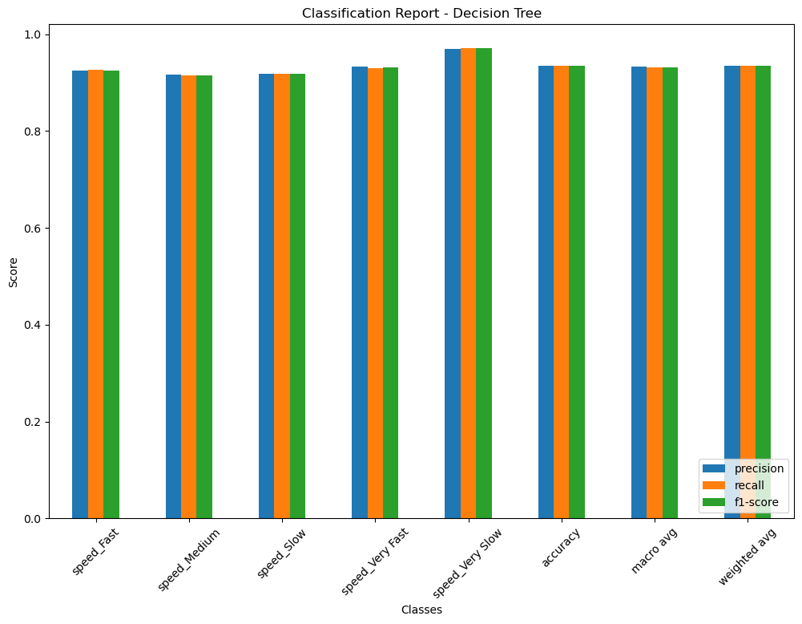

```python
conf_matrix_dt = confusion_matrix(y_test, y_pred_dt)
class_report_dt = classification_report(y_test, y_pred_dt, output_dict=True, zero_division=0)

# Plotting the Confusion Matrix for Decision Tree
plt.figure(figsize=(10, 7))
sns.heatmap(conf_matrix_dt, annot=True, fmt='d', cmap='Blues', xticklabels=y_test.unique(), yticklabels=y_test.unique())
plt.title('Confusion Matrix - Decision Tree')
plt.xlabel('Predicted Labels')
plt.ylabel('True Labels')
plt.show()

# Plotting the Classification Report for Decision Tree
report_df_dt = pd.DataFrame(class_report_dt).transpose()

report_df_dt[['precision', 'recall', 'f1-score']].plot(kind='bar', figsize=(12, 8))
plt.title('Classification Report - Decision Tree')
plt.ylabel('Score')
plt.xlabel('Classes')
plt.xticks(rotation=45)
plt.legend(loc='lower right')
plt.show()
```

Performs 5-fold cross-validation on the Decision Tree classifier, printing the accuracy scores for each fold and the mean accuracy

```python
from sklearn.model_selection import cross_val_score

# Perform 5-Fold Cross-Validation
cv_scores = cross_val_score(dt_clf, X_train, y_train, cv=5, scoring='accuracy')

# Print the Cross-Validation scores and their mean
print("Cross-validation scores:", cv_scores)
print("Mean cross-validation score:", cv_scores.mean())
```

```
Cross-validation scores: [0.92749118 0.92743827 0.92732584 0.92789242 0.92731245]
Mean cross-validation score: 0.9274920314428792
```

#### 5.7 Naive Bayes classifiers

Trains a Naive Bayes classifier on the training data, predicts the test labels, and evaluates the model's performance using a classification report and confusion matrix.

```python
from sklearn.naive_bayes import GaussianNB

nb_clf = GaussianNB()
nb_clf.fit(X_train, y_train)
y_pred_nb = nb_clf.predict(X_test)

print("Naive Bayes Classifier")
print("Classification Report:")
print(classification_report(y_test, y_pred_nb, zero_division=0))
print("\nConfusion Matrix:")
print(confusion_matrix(y_test, y_pred_nb))
```

```
Naive Bayes Classifier
Classification Report:
                 precision    recall  f1-score   support

     speed_Fast       0.40      0.77      0.52    189004
   speed_Medium       0.40      0.06      0.10    126051
     speed_Slow       0.38      0.11      0.17    126155
speed_Very Fast       0.69      0.13      0.21    125903
speed_Very Slow       0.52      0.85      0.64    188887

       accuracy                           0.45    756000
      macro avg       0.48      0.38      0.33    756000
   weighted avg       0.47      0.45      0.37    756000


Confusion Matrix:
[[144998   6037   3466   6491  28012]
 [ 65432   7476   6511    460  46172]
 [ 37000   3074  13693    122  72266]
 [103696   1060    845  15814   4488]
 [ 15824    982  11261    138 160682]]
```

Performs 5-fold cross-validation on a Naive Bayes classifier, printing the accuracy scores for each fold and the mean accuracy. It assesses the model's generalization across different training data subsets.

```python
from sklearn.naive_bayes import GaussianNB
from sklearn.model_selection import cross_val_score

# Initialize the Naive Bayes classifier
nb_clf = GaussianNB()

# Perform 5-fold cross-validation and calculate the accuracy
cv_scores = cross_val_score(nb_clf, X_train, y_train, cv=5, scoring='accuracy')

# Print the cross-validation scores and the average score
print("Cross-validation scores:", cv_scores)
print("Mean cross-validation score:", cv_scores.mean())
```

```
Cross-validation scores: [0.45106702 0.45300705 0.4575463  0.45404762 0.44965708]
Mean cross-validation score: 0.4530650130763121
```

Visualizes the Naive Bayes model's performance by generating a confusion matrix heatmap and a bar chart showing precision, recall, and F1-scores.

[figure not shown]

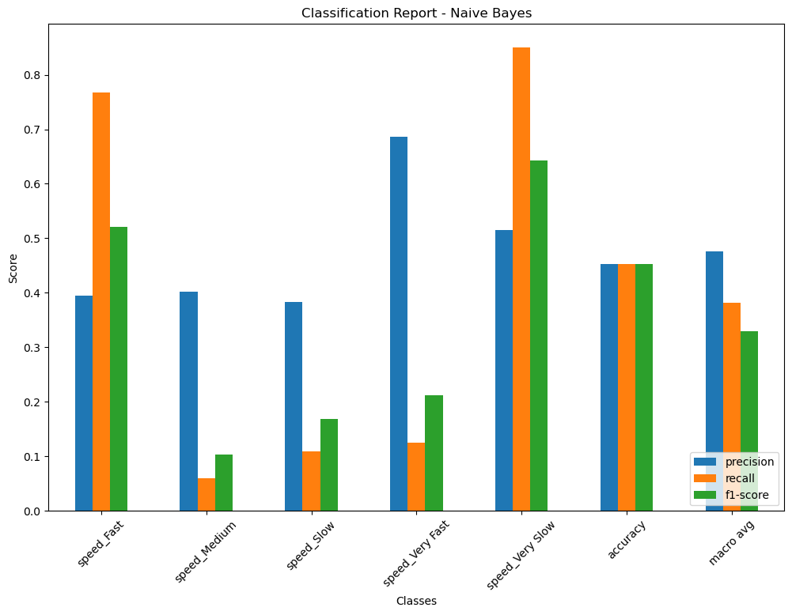

```python
import matplotlib.pyplot as plt
import seaborn as sns
# Plot the confusion matrix
conf_matrix_nb = confusion_matrix(y_test, y_pred_nb)
plt.figure(figsize=(10, 7))
sns.heatmap(conf_matrix_nb, annot=True, fmt='d', cmap='Blues', xticklabels=y_test.unique(), yticklabels=y_test.unique())
plt.title('Confusion Matrix - Naive Bayes')
plt.xlabel('Predicted Labels')
plt.ylabel('True Labels')
plt.show()

# Plotting the Classification Report
class_report_nb = classification_report(y_test, y_pred_nb, output_dict=True, zero_division=0)
report_df_nb = pd.DataFrame(class_report_nb).transpose()

# Plot precision, recall, and F1-score as bar charts
report_df_nb[['precision', 'recall', 'f1-score']].iloc[:-1].plot(kind='bar', figsize=(12, 8))
plt.title('Classification Report - Naive Bayes')
plt.ylabel('Score')
plt.xlabel('Classes')
plt.xticks(rotation=45)
plt.legend(loc='lower right')
plt.show()
```

#### 5.8 SVM CLASSIFIERS

Processes a large dataset in chunks to train and evaluate an SVM with an RBF kernel, calculating overall accuracy, and generating a classification report and confusion matrix. It efficiently handles large data by training on each chunk and aggregating the results.

```python
from sklearn.svm import SVC
from sklearn.metrics import accuracy_score, classification_report, confusion_matrix
from sklearn.model_selection import train_test_split, cross_validate
import numpy as np

# Initialize lists to store all predictions and true labels
all_y_true = []
all_y_pred = []

# Function to process each chunk
def process_chunk_for_svm(chunk, model):
    X_chunk = chunk.drop(['speed', 'speed_Very Slow', 'speed_Slow', 'speed_Medium', 'speed_Fast', 'speed_Very Fast'], axis=1)
    y_chunk = chunk.loc[:, 'speed_Very Slow':'speed_Very Fast']
    y_labels_chunk = y_chunk.idxmax(axis=1)

    # Split into training and test sets
    X_train_chunk, X_test_chunk, y_train_chunk, y_test_chunk = train_test_split(X_chunk, y_labels_chunk, test_size=0.25, random_state=42)

    if len(y_train_chunk.unique()) > 1:  # Ensure at least two classes are present
        model.fit(X_train_chunk, y_train_chunk)
        y_pred_chunk = model.predict(X_test_chunk)

        # Append to the lists
        all_y_true.extend(y_test_chunk)
        all_y_pred.extend(y_pred_chunk)
    else:
        print("Skipping chunk due to single class label.")

# Loop through the data in chunks
chunk_size = 10000
num_chunks = len(data_pca_encoded) // chunk_size + 1
model = SVC(kernel='rbf', random_state=42)  # Using SVM with RBF kernel

for i in range(num_chunks):
    start_idx = i * chunk_size
    end_idx = min((i + 1) * chunk_size, len(data_pca_encoded))
    chunk = data_pca_encoded.iloc[start_idx:end_idx]
    print(f"Processing chunk {i+1}/{num_chunks}, with indices: {start_idx} to {end_idx}")
    process_chunk_for_svm(chunk, model)

# Calculate overall accuracy
overall_accuracy = accuracy_score(all_y_true, all_y_pred)
print(f"Overall Accuracy of SVM: {overall_accuracy:.4f}")

print("\nClassification Report:")
print(classification_report(all_y_true, all_y_pred, zero_division=0))

print("\nConfusion Matrix:")
print(confusion_matrix(all_y_true, all_y_pred))
```

[output not shown]

[output cut: 469 more lines]

```
     speed_Slow       0.98      0.99      0.98     53490
speed_Very Fast       0.98      0.98      0.98     50000
speed_Very Slow       0.99      0.99      0.99     51510

       accuracy                           0.98    260000
      macro avg       0.98      0.98      0.98    260000
   weighted avg       0.98      0.98      0.98    260000


Confusion Matrix:
[[52782   318     0   903     0]
 [  639 49822   536     0     0]
 [    0   395 52729     0   366]
 [  998     0     0 49002     0]
 [    0     0   727     4 50779]]
```

A heatmap to visualize the SVM model's confusion matrix, comparing true and predicted labels across all classes.

[figure not shown]

```python
import matplotlib.pyplot as plt
import seaborn as sns
from sklearn.metrics import confusion_matrix, classification_report

# Confusion Matrix Heatmap
cm = confusion_matrix(all_y_true, all_y_pred)
plt.figure(figsize=(10, 7))
sns.heatmap(cm, annot=True, fmt='d', cmap='Blues', xticklabels=model.classes_, yticklabels=model.classes_)
plt.title('Confusion Matrix- SVM')
plt.xlabel('Predicted')
plt.ylabel('True')
plt.show()
```

Bar plots to visualize precision, recall, and F1-scores from the SVM model's classification report across all classes

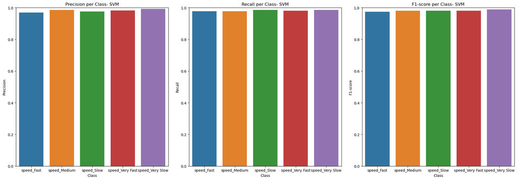

```python
import matplotlib.pyplot as plt
import seaborn as sns
from sklearn.metrics import classification_report

# Generate the classification report
report = classification_report(all_y_true, all_y_pred, output_dict=True, zero_division=0)

# Define the metrics and labels
metrics = ['precision', 'recall', 'f1-score']
labels = list(report.keys())[:-3]  # Extracting class labels

# Create subplots
fig, axes = plt.subplots(1, 3, figsize=(20, 7))

# Plot each metric
for i, metric in enumerate(metrics):
    values = [report[label][metric] for label in labels]
    sns.barplot(ax=axes[i], x=labels, y=values)
    axes[i].set_title(f'{metric.capitalize()} per Class- SVM')
    axes[i].set_ylim(0, 1)
    axes[i].set_xlabel('Class')
    axes[i].set_ylabel(metric.capitalize())
plt.tight_layout()
plt.show()
```